# Visualizations - STARTER

## Histograms

### geom_histogram()

```r
ggplot(data = diamonds)
```

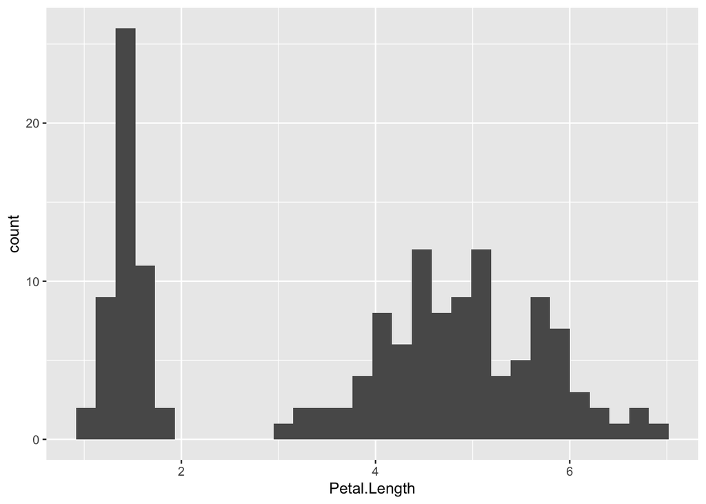

```r
ggplot(data = iris,
       aes(x = Petal.Length)) +
  geom_histogram()
```

### Exercise

- Use the code chunk below to create a histogram for `carat` that has 20 bins with white bars and black outlines.

### Titles and labels

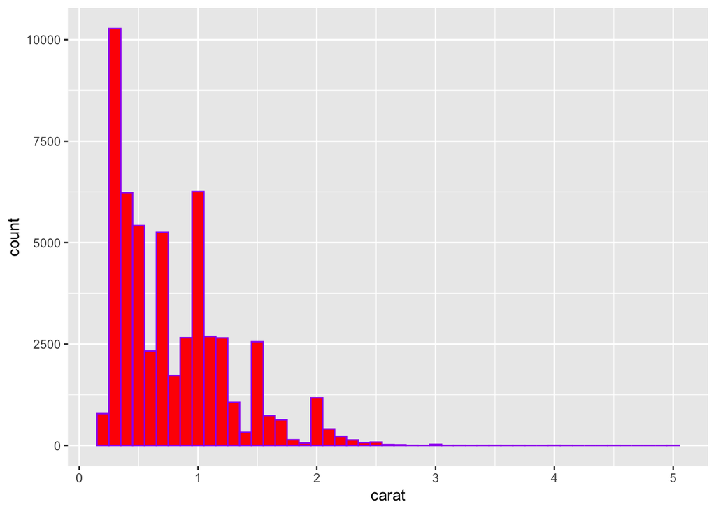

```r
ggplot(data = diamonds,
       aes(x = carat)) +
  geom_histogram(binwidth = 0.1,
                 fill = "red",
                 color = "purple")
```

## Boxplots

### geom_boxplot()

```r
x <- rnorm(50)
summary(x)
```

```
   Min. 1st Qu.  Median    Mean 3rd Qu.    Max.
-2.3711 -0.8143 -0.1666 -0.1534  0.5768  1.9082
```

```r
ggplot(data = diamonds)
```

### Exercise

- Using the code chunk below, create a *vertical* boxplot of `Sepal.Length` using the *iris* dataset.

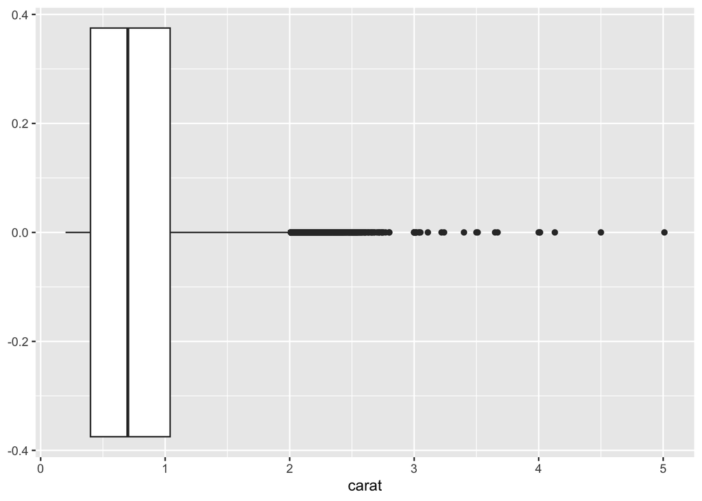

```r
ggplot(data = diamonds,
aes(x = carat)) +
  geom_boxplot()
```

### Transformations and more customizations

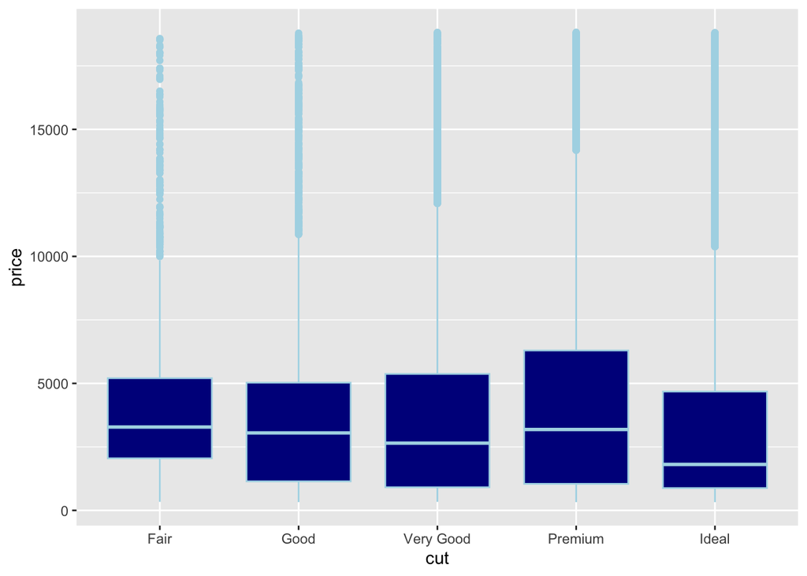

```r
ggplot(data = diamonds,
       aes(x = cut,
           y = price)) +
  geom_boxplot(fill = "darkblue",
               color = "lightblue")
```

### Exercise

- Using the code chunk below, create a comparative boxplot using the *iris* dataset that includes the following features:
  1. Compares `Sepal.Length` for each `Species`;
  2. Horizontal boxplots (more than one way to do this);
  3. `Sepal.Length` is originally measured in millimeters (mm); convert this to meters (m) for this plot;
  4. More informative axis label for `Sepal.Length` based on new scale;
  5. A cool theme (try a few!).